# **Predicting Barbell Performance with Machine Learning**

Chand Sooran

November 22, 2015

### **Human Activity Recognition**

#### **Building the Models**

In building the models, I had to download the data, partition the data into a training set and a testing set, remove unnecessary features, and ensure that all of the data was in a format that would permit model building.

As the first step in cleaning the data, I removed any variables where missing values made up more than 97% of the data, in addition to removing several columns whose only constituents were #DIV/0! errors.

A number of variables were classified as factor variables, despite having summary statistical data (e.g. “kurtosis_roll_belt”). I changed these into numerics in order to include them more suitably in analysis, as in the following example.

```r
## kurtosis_roll_belt
newtraining$kurtosis_roll_belt <- as.character(newtraining$kurtosis_roll_belt)
newtraining$kurtosis_roll_belt <- as.numeric(newtraining$kurtosis_roll_belt)
newtraining$kurtosis_roll_belt[is.na(newtraining$kurtosis_roll_belt)] <- 0

newtesting$kurtosis_roll_belt <- as.character(newtesting$kurtosis_roll_belt)
newtesting$kurtosis_roll_belt <- as.numeric(newtesting$kurtosis_roll_belt)
newtesting$kurtosis_roll_belt[is.na(newtesting$kurtosis_roll_belt)] <- 0
```

Finally, I removed the first seven columns. These contained descriptive information, such as the names of the individuals participants. With six participants and only five potential classes of performance, I thought that this was the type of feature that might cloud the performance of the model on a subsequent testing set.

#### **Exploratory Data Analysis**

Next, I plotted the charts of each of the remaining features against the outcome variable, as in this plot of the “roll_belt” feature against “classe”, in order to see which variables had expanatory power, and to understand the overlap of explanatory power between features. Here, one can see that the “roll_belt” feature is much lower for correctly performing the exercise than for making a mistake, with each of the four possible mistakes looking broadly similar. If anything, Class E has greater variability in “roll_belt”.

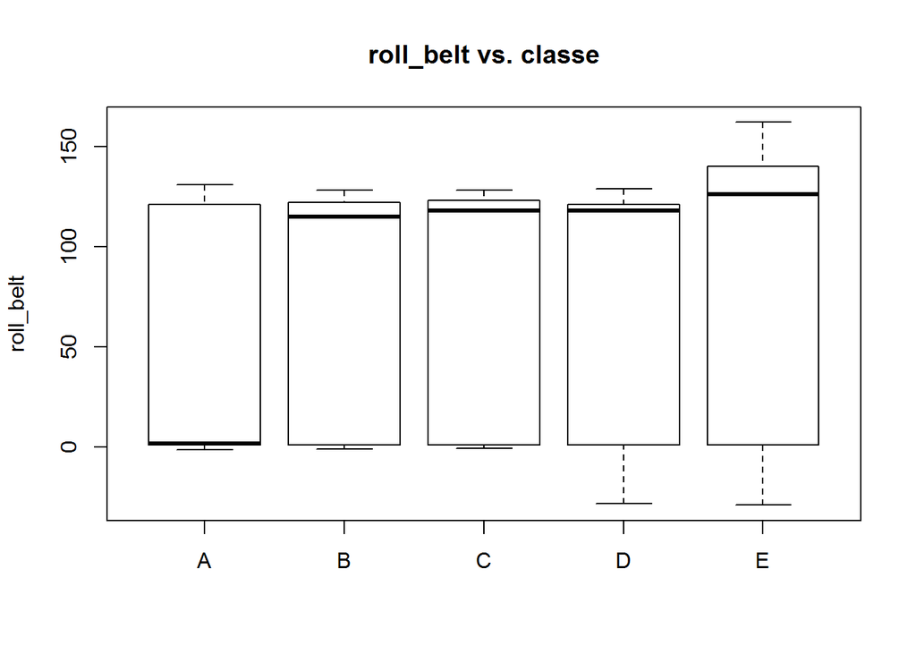

I also identified pairs of predictor variables with high correlations and I found that there was a significant number of pairs of these highly correlated predictors, using the following code.

```r
## Check correlations
M <- abs(cor(newnewtraining[,-77]))
diag(M) <- 0
MM <- which(M > 0.8, arr.ind = T) ## There is plenty of correlation
```

#### **Principal Components**

Given the large set of potential explanatory variables, I started with principal components analysis in order to try to reduce the number of predictors. Also, I was motivated by the large number of pairs of highly correlated predictors.

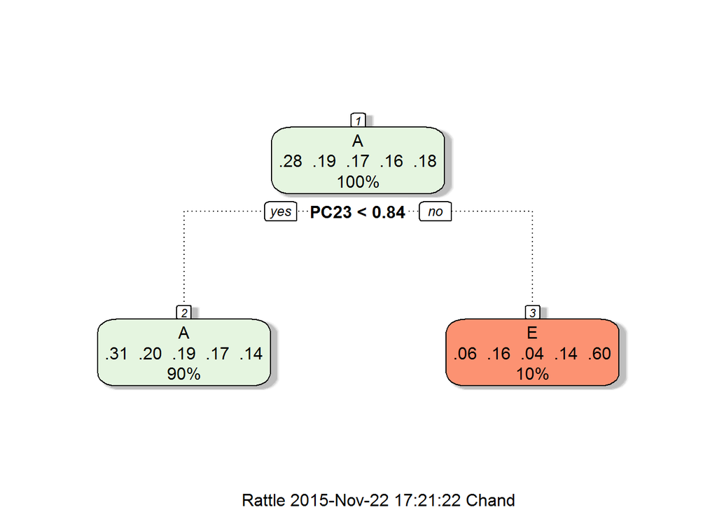

```r
## Train the class partition with Principal Components, given all the correlation
modPC <- train(classe ~ ., data = newnewtraining, preProcess = c("center","scale", "pca"), method = "rpart")
fancyRpartPlot(modPC$finalModel)
```

```r
## predPC <- predict(modPC, newdata = newnewtesting)
## print(confusionMatrix(predPC, newnewtesting$classe))
```

However, the partition plot and the confusion matrix showed that the principal components approach only selected A or E, with accuracy only 33.58% of the time and a Kappa of 0.0851. The out-of-sample error here was 66.42%.

#### **Classification Tree**

Next, I chose to look at a classification tree. Here is the code for training the model. I decided to consider a Classification Tree next for its intuitive appeal.

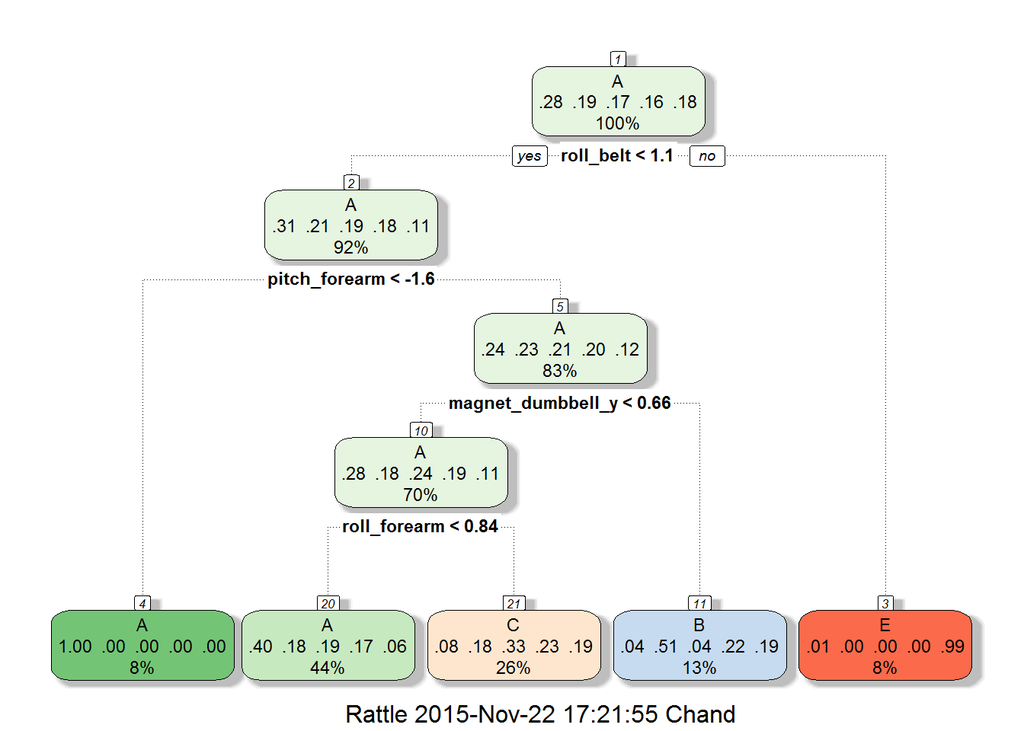

```r
modPart <- train(classe ~ ., data = newnewtraining, preProcess = c("center","scale"), method = "rpart")
fancyRpartPlot(modPart$finalModel)
```

```r
predPart <- predict(modPart, newdata = newnewtesting) ## Left is predictions, top is actual
## modPart ## Accuracy 51.75%, Kappa 37.3%, Cp 3.56%
## modPart$finalModel
## print(modPart$results)
## print(confusionMatrix(predPart, newnewtesting$classe))
```

The classification tree did much better with accuracy of 49.88% and a Kappa of 0.3456. The out of sample error was 50.12%.

#### **Random Forest**

Extending the classification tree to a random forest, **using cross-validation**, as shown in the following code.

```r
registerDoSNOW(makeCluster(4, type = "SOCK"))

x <- newnewtraining[,-77]
y <- newnewtraining[,77]

rf <- foreach(ntree = rep(250,4), .combine = combine, .packages = "randomForest") %dopar%
  randomForest(x, y, ntree = ntree)

predrf <- predict(object = rf, newdata = newnewtesting)
## print(table(predrf, newnewtesting$classe))
print(confusionMatrix(predrf, newnewtesting$classe))
```

```
## Confusion Matrix and Statistics
##
##           Reference
## Prediction    A    B    C    D    E
##          A 1395    6    0    0    0
##          B    0  939    3    0    0
##          C    0    4  852   11    0
##          D    0    0    0  793    4
##          E    0    0    0    0  897
##
## Overall Statistics
##
##                Accuracy : 0.9943
##                  95% CI : (0.9918, 0.9962)
##     No Information Rate : 0.2845
##     P-Value [Acc > NIR] : < 2.2e-16
##
##                   Kappa : 0.9928
##  Mcnemar's Test P-Value : NA
##
## Statistics by Class:
##
##                      Class: A Class: B Class: C Class: D Class: E
## Sensitivity            1.0000   0.9895   0.9965   0.9863   0.9956
## Specificity            0.9983   0.9992   0.9963   0.9990   1.0000
## Pos Pred Value         0.9957   0.9968   0.9827   0.9950   1.0000
## Neg Pred Value         1.0000   0.9975   0.9993   0.9973   0.9990
## Prevalence             0.2845   0.1935   0.1743   0.1639   0.1837
## Detection Rate         0.2845   0.1915   0.1737   0.1617   0.1829
## Detection Prevalence   0.2857   0.1921   0.1768   0.1625   0.1829
## Balanced Accuracy      0.9991   0.9944   0.9964   0.9927   0.9978
```

#### **Bagging**

The next model I built was Bagging, bootstrap aggregation with 10 bootstraps, as another implementation of the cross-validation approach.

```r
## Train with bagging
BagTraining <- newnewtraining
BagPredictors <- BagTraining[, -77]
BagOutcome <- BagTraining[,77]

treebag <- bag(x = BagPredictors, y = BagOutcome, B = 10,
                  bagControl = bagControl(fit = ctreeBag$fit,
                  predict = ctreeBag$pred,
                  aggregate = ctreeBag$aggregate,
                  oob = TRUE))

predBag <- predict(treebag, newdata = newnewtesting[,-77])
print(table(predBag, newnewtesting$classe))
```

```
##
## predBag    A    B    C    D    E
##       A 1360   32    3    5    1
##       B   13  889   18    6   17
##       C    2   20  821   28    5
##       D   16    3   11  760    9
##       E    4    5    2    5  869
```

```r
## print(confusionMatrix(predBag, newnewtesting$classe))
```

#### **Boosting**

My next attempt at modeling with cross-validation was a boosting model.

```r
## Train with boosting
gbmControl <- trainControl(method = "repeatedcv", ## Resampling method (eg. boot, boot632, cv, repeatedcv, LOOCV, LGOCV)
                           number = 5, ## Number of folds
                           repeats = 1, ## The number of complete sets of folds to compute
                           verboseIter = TRUE) ## Print a training log = TRUE

set.seed(25020)

modGBM2 <- train(classe ~ ., data = newnewtraining,
                 method = "gbm",
                 trControl = gbmControl,
                 verbose = FALSE)
predGBM2 <- predict(modGBM2, newnewtesting)
## confusionMatrix(predGBM2, newnewtesting$classe)
```

Here, boosting had an accuracy of 96.31% and a Kappa of 95.31%. The out-of-sample error was 3.69%.

#### **Linear Discriminant Analysis**

I attempted to build a linear discriminant analysis model, again using cross-validation.

```r
## Train with linear discriminant analysis
modLDA <- train(classe ~ ., data = newnewtraining, method = "lda")
predLDA <- predict(modLDA, newdata = newnewtesting)
print(table(predLDA, newnewtesting$classe))
```

```
##
## predLDA    A    B    C    D    E
##       A 1135  157   89   51   31
##       B   30  603   86   26  158
##       C  103  123  551   91   86
##       D  125   30  107  603   93
##       E    2   36   22   33  533
```

```r
print(modLDA$results)
```

```
##   parameter  Accuracy     Kappa AccuracySD    KappaSD
## 1      none 0.6997902 0.6200644 0.00620157 0.00778313
```

```r
## print(confusionMatrix(predLDA, newnewtesting$classe))
```

#### **Naive Bayes**

Finally, I built a Naive Bayes model with repeated cross-validation.

```r
## nbControl <- trainControl(method = "repeatedcv",
                          ## number = 5,
                          ## repeats = 1,
                          ## verboseIter = TRUE)

## set.seed(42872)

## modNB3 <- train(classe ~ ., data = newnewtraining,
                 ## method = "nb",
                 ## trControl = nbControl,
                 ## verbose = FALSE)

## predNB3 <- predict(modNB3, newnewtesting)
## print(confusionMatrix(predNB3, newnewtesting$classe))
```

The Naive Bayes model had an accuracy of 63.09% and a Kappa of 54.55%.The out-of-sample error was 36.91%.

### **Conclusion: The Best Model Was the Random Forest**

Based on accuracy and Kappa, I selected the Random Forest model as the best model. Cross-validation was my preferred approach after the limited success I had with a principal components approach and with the initial classification tree, given the breadth and variability in the predictor variables. Boosting and bagging were close behind, suggesting some validity to the selection of cross-validation as an approach.